# Industry GHG

This memo records the result from industry_GHG.r.

- Manufacutre emission distribution (384 ind)

```r
######### Part A. preparation
library(dplyr)
library(ggplot2)
library(tidyr)
#(i)load GHG data
GHG_IO=read.csv(file="GHGIO.csv",header=T, as.is=T)
GHG_IO[is.na(GHG_IO)]=0
GHG_IO_ind=GHG_IO[,colnames(GHG_IO)!="HE"]
GHG_IO_F=GHG_IO[,colnames(GHG_IO)=="HE"]

#load index mapping
sector_ind=read.csv(file="indcode_20161223.csv",header=T, as.is=T)
indname=read.csv(file="indname.csv",header=T, as.is=T)
```

To select energy intensive industry, we obtain share of emission by each manufacture among total emission from manufactutre. So we excludes AFF (1-25), Mining(26-34), Refined Oil (99-108), Service (281-286,302-384), Construction (287-301) on IO table. Then we aggregate emissions by industries, and optain emission share for each industry. Then we select industries with largest emission that covers 90% of total manufacture emissions.

```r
# obtain share and cumulative share (distribution function) of ghg from manufacture (35:98,109:271)
GHG_ind_dist=GHG_IO_ind %>% gather(key="ind",value,c(35:98,109:271)) %>% group_by(ind) %>% summarise(ind_ghg=sum(value)) %>% mutate(share=ind_ghg/sum(ind_ghg)) %>% arrange(desc(share)) %>% mutate(dist=cumsum(share))

#add names
indname$xcode=paste("X",indname$basecode,sep="")
GHG_ind_dist.N=merge(GHG_ind_dist,indname,by.x="ind",by.y="xcode",all.x=T)

GHG_ind_dist.N=GHG_ind_dist.N[order(GHG_ind_dist.N$share,decreasing=T),]

# keep top emitters covering 90% of emission
Top_ind=GHG_ind_dist.N %>% filter(dist<0.9) %>% arrange(desc(share)) %>% select(ind_ghg,share,dist,basename)
print(Top_ind)
```

```
##       ind_ghg       share      dist                          basename
## 1  72111376.2 0.484288357 0.4842884                              선철
## 2  18713514.5 0.125676941 0.6099653                   지방족 기초유분
## 3  11364981.3 0.076325379 0.6862907                   방향족 기초유분
## 4   9219385.1 0.061915901 0.7482066                            시멘트
## 5   2026555.8 0.013610021 0.7618166                    기초무기화합물
## 6   1846020.1 0.012397573 0.7742142                              조강
## 7   1533543.5 0.010299030 0.7845132                  제조임가공서비스
## 8   1368609.1 0.009191357 0.7937046               LCD 평판 디스플레이
## 9   1336970.4 0.008978878 0.8026834                            합금철
## 10  1223687.2 0.008218086 0.8109015                  석회 및 석고제품
## 11  1186364.8 0.007967434 0.8188690           아스콘 및 아스팔트 제품
## 12  1155165.1 0.007757902 0.8266269                  석유화학중간제품
## 13   998348.5 0.006704747 0.8333316                          금속처리
## 14   922339.9 0.006194286 0.8395259               전자기기용 유리제품
```

[output cut: 20 more lines]

The pdf and cdf of industrial emission is given as follows.

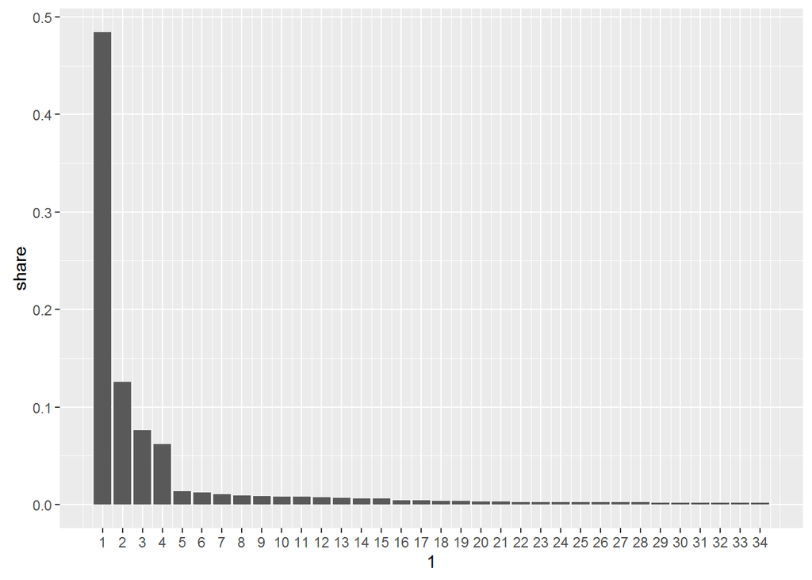

```r
Top_ind %>%ggplot(aes(x=(1:34),y=share))+geom_bar(stat="identity")+scale_x_continuous(breaks=c(1:34),labels(Top_ind$basename))
```

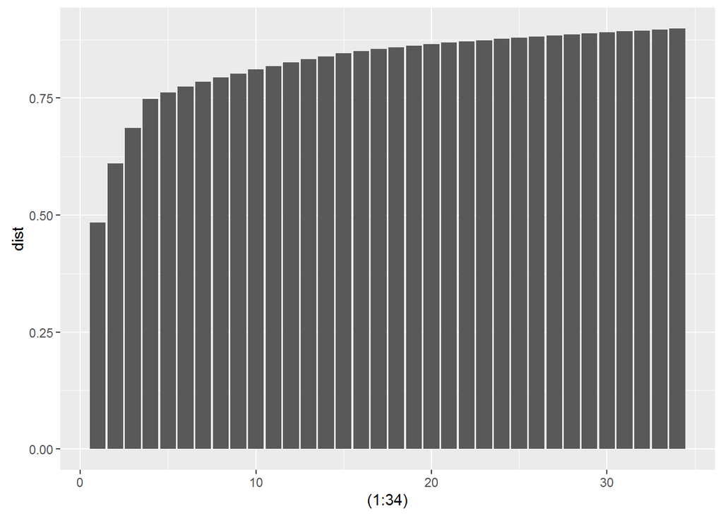

```r
Top_ind %>%ggplot(aes(x=(1:34),y=dist))+geom_bar(stat="identity")
```

- Manufacutre emission distribution (49 ind)

```r
#(ii)preparing index
#row_ind=sector_ind[,1:2]
col_ind=sector_ind[,3:4]
sec_group=sector_ind[,5:8]
#sec_BR=sector_ind[,c(5,6,15,16)]

#IOind_model=row_ind[(1:384),]
sec_group=sec_group[!is.na(sec_group[,1]),]
#sec_BR=sec_BR[!is.na(sec_BR[,1]),]
sectorname=sec_group[,1:2]
```

We aggregated industry emission of 384 industries according to our standard model sector definition. Then we select sectors with largest emission that covers 95% of total manufacture emissions.

```r
GHG_ind_core=GHG_IO_ind %>% gather(key="ind",value,c(35:98,109:271)) %>% group_by(ind) %>% summarise(ind_ghg=sum(value))

col_ind$xcode=paste("X",col_ind$basecode_column,sep="")

GHG_sector=merge(GHG_ind_core,col_ind,by.x="ind",by.y="xcode",all.x=T)
GHG_sector_dist=GHG_sector %>% group_by(sector_column) %>% summarize(sector_ghg=sum(ind_ghg))%>% mutate(share=sector_ghg/sum(sector_ghg)) %>% arrange(desc(sector_ghg)) %>% mutate(dist=cumsum(share))
sectorname=sec_group[,1:2]

GHG_sector_dist.N=merge(GHG_sector_dist,sectorname, by.x="sector_column",by.y="sector_ind",all.x=T,sort=F)

Top_sector=GHG_sector_dist.N %>% filter(dist<0.95) %>% arrange(desc(share))
print(Top_sector)
```

```
##   sector_column sector_ghg      share      dist sector_name
## 1            10   76921198 0.51659034 0.5165903          IS
## 2            12   33158859 0.22268954 0.7392799     Orgchem
## 3            25   10452199 0.07019528 0.8094752    MissManu
## 4            11   10127208 0.06801269 0.8774879      Cement
## 5            15    4763822 0.03199306 0.9094809     Mineral
## 6            16    1784716 0.01198586 0.9214668  nonISmetal
## 7            17    1780003 0.01195421 0.9334210     Machine
## 8            22    1613792 0.01083796 0.9442590        Auto
```

The pdf and cdf of industrial emission is given as follows. Notice that only the top 4 industries has larger than 5% share, and they take up 88% of industry emission. (It would be sufficient to have separate model for three. IS/Orgchem/Cement)

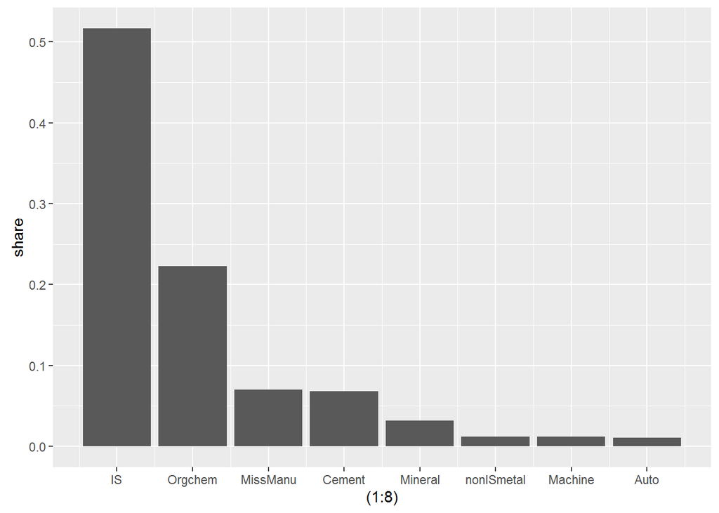

```r
Top_sector%>%ggplot(aes(x=(1:8),y=share))+geom_bar(stat="identity")+scale_x_continuous(breaks=(1:8),labels=(Top_sector$sector_name))
```

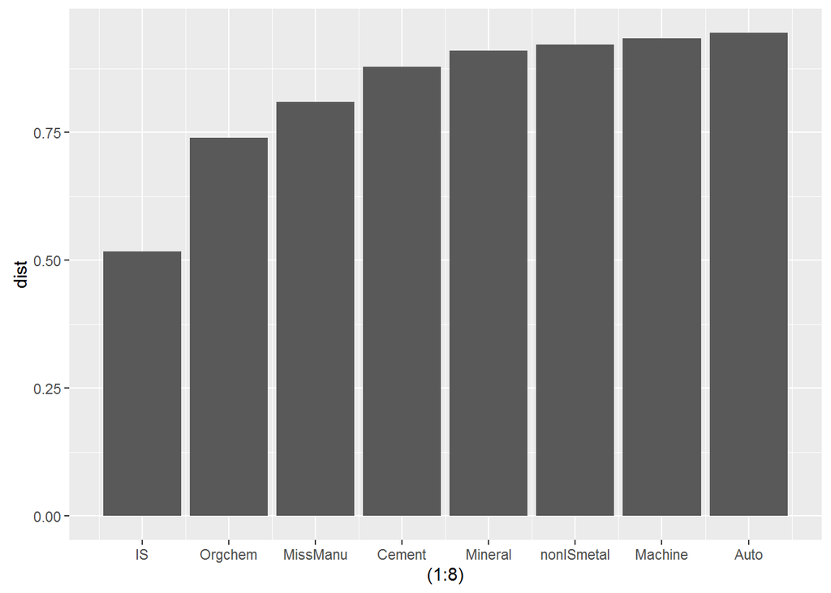

```r
Top_sector%>%ggplot(aes(x=(1:8),y=dist))+geom_bar(stat="identity")+scale_x_continuous(breaks=(1:8),labels=(Top_sector$sector_name))
```